# Numpy (tableaux de données multi-dimensionnels)

# et matplotlib (visualisation en 2D et 3D pour Python)

```
Alexandre Gramfort : alexandre.gramfort@inria.fr
```

```python
# et JUSTE POUR MOI (pour avoir les figures dans le notebook)
%matplotlib inline
```

## Introduction

- `numpy` est un module utilisé dans presque tous les projets de calcul numérique sous Python
  - Il fournit des structures de données performantes pour la manipulation de vecteurs, matrices et tenseurs plus généraux
  - `numpy` est écrit en C et en Fortran d'où ses performances élevées lorsque les calculs sont vectorisés (formulés comme des opérations sur des vecteurs/matrices)
- `matplotlib` est un module performant pour la génération de graphiques en 2D et 3D
  - syntaxe très proche de celle de Matlab
  - supporte texte et étiquettes en $\LaTeX$
  - sortie de qualité dans divers formats (PNG, PDF, SV, EPS...)
  - interface graphique intéractive pour explorer les figures

Pour utiliser `numpy` et `matplotlib` il faut commencer par les importer :

```python
import numpy as np
import matplotlib.pyplot as plt
```

## *Arrays* `numpy`

Dans la terminologie `numpy`, vecteurs, matrices et autres tenseurs sont appelés *arrays*.

## Création d'*arrays* `numpy`

Plusieurs possibilités:

- a partir de listes ou n-uplets Python
- en utilisant des fonctions dédiées, telles que `arange`, `linspace`, etc.
- par chargement à partir de fichiers

### A partir de listes

Au moyen de la fonction `numpy.array` :

```python
# un vecteur: l'argument de la fonction est une liste Python
v = np.array([1, 3, 2, 4])
print(v)
print(type(v))
```

```
[1 3 2 4]
<class 'numpy.ndarray'>
```

On peut alors visualiser ces données :

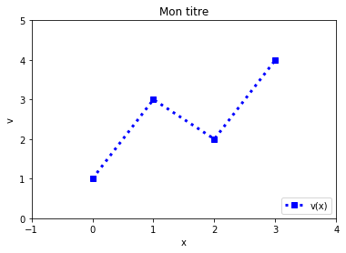

```python
v = np.array([1, 3, 2, 4])
x = np.array([0, 1, 2, 3])

plt.figure()
plt.plot(x, v, 'bs:', label='v(x)', linewidth=3)
plt.legend(loc='lower right')
plt.xlabel('x')
plt.ylabel('v')
plt.title('Mon titre')
plt.xlim([-1, 4])
plt.ylim([0, 5])
plt.show()
plt.savefig('image.png')  # on sauve la figure
```

On peut omettre `show()`, lorsque la méthode `ion()` a été appelée ; c'est le cas dans Spyder et pylab

Pour définir une matrice (array de dimension 2 pour numpy):

```python
# une matrice: l'argument est une liste emboitée
M = np.array([[1, 2], [3, 4]])
print(M)
```

```
[[1 2]
 [3 4]]
```

```python
M[1, 0]
```

```
3
```

Les objets `v` et `M` sont tous deux du type `ndarray` (fourni par `numpy`)

```python
type(v), type(M)
```

```
(numpy.ndarray, numpy.ndarray)
```

`v` et `M` ne diffèrent que par leur taille, que l'on peut obtenir via la propriété `shape` :

```python
v.shape
```

```
(4,)
```

```python
M.shape
```

```
(2, 2)
```

Pour obtenir le nombre d'éléments d'un *array* :

```python
v.size
```

```
4
```

```python
M.size
```

```
4
```

On peut aussi utiliser `numpy.shape` et `numpy.size`

```python
np.shape(M)
```

```
(2, 2)
```

Les *arrays* ont un type qu'on obtient via `dtype`:

```python
print(M)
print(M.dtype)
```

```
[[1 2]
 [3 4]]
int64
```

Les types doivent être respectés lors d'assignations à des *arrays*

```python
M[0,0] = "hello"
```

```
---------------------------------------------------------------------------
ValueError                                Traceback (most recent call last)
<ipython-input-14-e1f336250f69> in <module>()
----> 1 M[0,0] = "hello"

ValueError: invalid literal for int() with base 10: 'hello'
```

On peut définir le type de manière explicite en utilisant le mot clé `dtype` en argument:

```python
v.dtype
```

```
dtype('int64')
```

```python
M = np.array([[1, 2], [3, 4]], dtype=complex)
M
```

```
array([[ 1.+0.j,  2.+0.j],
       [ 3.+0.j,  4.+0.j]])
```

```python
M.dtype
```

```
dtype('complex128')
```

- Autres types possibles avec `dtype` : `int`, `float`, `complex`, `bool`, `object`, etc.
- On peut aussi spécifier la précision en bits: `int64`, `int16`, `float128`, `complex128`.

```python
v.shape
```

```
(4,)
```

```python
v.shape
```

```
(4,)
```

```python
v.ndim
```

```
1
```

```python
M.ndim
```

```
2
```

### Utilisation de fonction de génération d'*arrays*

#### arange

```python
# create a range
x = np.arange(0, 10, 2) # arguments: start, stop, step
x
```

```
array([0, 2, 4, 6, 8])
```

```python
x = np.arange(-1, 1, 0.1)
x
```

```
array([ -1.00000000e+00,  -9.00000000e-01,  -8.00000000e-01,
        -7.00000000e-01,  -6.00000000e-01,  -5.00000000e-01,
        -4.00000000e-01,  -3.00000000e-01,  -2.00000000e-01,
        -1.00000000e-01,  -2.22044605e-16,   1.00000000e-01,
         2.00000000e-01,   3.00000000e-01,   4.00000000e-01,
         5.00000000e-01,   6.00000000e-01,   7.00000000e-01,
         8.00000000e-01,   9.00000000e-01])
```

#### linspace

```python
# avec linspace, le début et la fin SONT inclus
np.linspace(0, 10, 25)
```

```
array([  0.        ,   0.41666667,   0.83333333,   1.25      ,
         1.66666667,   2.08333333,   2.5       ,   2.91666667,
         3.33333333,   3.75      ,   4.16666667,   4.58333333,
         5.        ,   5.41666667,   5.83333333,   6.25      ,
         6.66666667,   7.08333333,   7.5       ,   7.91666667,
         8.33333333,   8.75      ,   9.16666667,   9.58333333,  10.        ])
```

```python
np.linspace(0, 10, 11)
```

```
array([  0.,   1.,   2.,   3.,   4.,   5.,   6.,   7.,   8.,   9.,  10.])
```

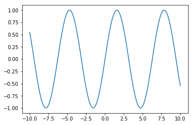

```python
xx = np.linspace(-10, 10, 100)
plt.plot(xx, np.sin(xx));
```

#### Données aléatoires

```python
from numpy import random
```

```python
# tirage uniforme dans [0,1]
random.rand(5, 5)  # ou np.random.rand
```

```
array([[ 0.94750787,  0.0854536 ,  0.08464133,  0.51064049,  0.92290385],
       [ 0.96749051,  0.04515253,  0.82042134,  0.83301317,  0.95993249],
       [ 0.97389347,  0.97310147,  0.22561721,  0.73032053,  0.58498454],
       [ 0.63442089,  0.69953858,  0.13506587,  0.55979378,  0.95221183],
       [ 0.24909073,  0.9075087 ,  0.92732018,  0.16703459,  0.16130844]])
```

```python
# tirage suivant une loi normale standard
random.randn(5, 5)
```

```
array([[-0.40631721, -0.07609417,  0.23380365,  1.04090199, -1.62321857],
       [-0.14337524,  0.01129988, -1.25928425, -0.29491756,  0.33854559],
       [ 1.10905579,  1.21313526,  1.74320782, -1.07890097, -0.60722017],
       [ 0.911712  , -1.44332066, -1.52627915,  0.59141964, -0.24174463],
       [-1.90148563,  0.02040568,  0.43810568, -0.12291265,  0.11618367]])
```

Affichage de l'histogramme des tirages

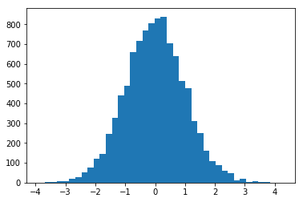

```python
a = random.randn(10000)
hh = plt.hist(a, 40)
```

**EXERCISE: Distribution de Laplace**:

- Générez $10^3$ points suivants une distribution de Laplace et visualisez l'histogramme

#### zeros et ones

Très utiles pour allouer des tableaux en mémoire

```python
np.zeros((3,), dtype=int)
```

```
array([0, 0, 0])
```

```python
np.ones((3, 3))  # attention np.ones(3,3) est FAUX
```

```
array([[ 1.,  1.,  1.],
       [ 1.,  1.,  1.],
       [ 1.,  1.,  1.]])
```

```python
print(np.zeros((3,), dtype=int))
print(np.zeros((1, 3), dtype=int))
```

```
[0 0 0]
[[0 0 0]]
```

```python
print(np.zeros((3, 1), dtype=int))
```

```
[[0]
 [0]
 [0]]
```

```python
col_vector = np.zeros((3, 1), dtype=int)
```

## Manipulation d'*arrays*

```python
v = np.array([1, 3, 2, 4])
M = np.array([[1, 2], [3, 4]])
```

### Indexation

```python
# v est un vecteur, il n'a qu'une seule dimension -> un seul indice
v[0]
```

```
1
```

```python
# M est une matrice, ou un array à 2 dimensions -> deux indices
M[1,1]
```

```
4
```

Contenu complet :

```python
M
```

```
array([[1, 2],
       [3, 4]])
```

La deuxième ligne :

```python
M[1]
```

```
array([3, 4])
```

```python
M[1].shape
```

```
(2,)
```

On peut aussi utiliser `:`

```python
M[1, :] # 2 ème ligne (indice 1)
```

```
array([3, 4])
```

```python
M[:, 1] # 2 ème colonne (indice 1)
```

```
array([2, 4])
```

```python
M[[0, 1], [0, 1]]
```

```
array([1, 4])
```

On peut assigner des nouvelles valeurs à certaines cellules :

```python
M[0, 0] = 10
```

```python
M
```

```
array([[10,  2],
       [ 3,  4]])
```

```python
# on peut aussi assigner des lignes ou des colonnes
M[1, :] = -1
```

```python
M
```

```
array([[10,  2],
       [-1, -1]])
```

## *Slicing* ou accès par tranches

*Slicing* fait référence à la syntaxe `M[start:stop:step]` pour extraire une partie d'un *array* :

```python
A = np.array([1, 2, 3, 4, 5])
A
```

```
array([1, 2, 3, 4, 5])
```

```python
A[1:3]
```

```
array([2, 3])
```

Les tranches sont modifiables :

```python
A[1:3] = [-2, -3]
A
```

```
array([ 1, -2, -3,  4,  5])
```

```python
A[:3] # les trois premiers éléments
```

```
array([ 1, -2, -3])
```

```python
A[3:] # à partir de l'indice 3
```

```
array([4, 5])
```

On peut utiliser des indices négatifs :

```python
A = np.array([1,2,3,4,5])
```

```python
A[-1] # le dernier élément
```

```
5
```

```python
A[-3:] # les 3 derniers éléments
```

```
array([3, 4, 5])
```

Le *slicing* fonctionne de façon similaire pour les *array* multi-dimensionnels

```python
A = np.array([[n+m*10 for n in range(5)] for m in range(5)])
A
```

```
array([[ 0,  1,  2,  3,  4],
       [10, 11, 12, 13, 14],
       [20, 21, 22, 23, 24],
       [30, 31, 32, 33, 34],
       [40, 41, 42, 43, 44]])
```

```python
A[1:4, 1:4]  # sous-tableau
```

```
array([[11, 12, 13],
       [21, 22, 23],
       [31, 32, 33]])
```

```python
A[[0, 1, 3]]
```

```
array([[ 0,  1,  2,  3,  4],
       [10, 11, 12, 13, 14],
       [30, 31, 32, 33, 34]])
```